#### kilometer’s

a junk space

home

### Deck考

スライドという日本語はsildeとdeckの両方の意味で使われているようです。 slideというと1枚。deckというとプレゼンテーション用のスライド1セット。 このdeckはいわゆるデッキですね。カードゲームではお馴染みの概念ですがつまり積み込んだ山札からカードを1枚ずつ切っていくようなイメージです。

#### スライドを作るな!?

スティーヴ・ジョブズ(Steve Jobs, 1955-2011)はスライドを使ったプレゼンテーションを禁止してたとか、「自分が何をしているかが分かっている人はパワーポイントを必要としない」と言ったとか、ググるとそんな話が出て来ます。しかしこんな記事でもプレゼンテーションについて書こうとしたら触れておきたくなるくらいに、ジョブズは優れたプレゼンテーターとして知られています。もはや崇拝されているというレベルですね。この矛盾はなんなんでしょうか。とかく、こういう「有名人がこう言った」系の話は創作であることも多く、元の情報を探してみました。

恐らくこの文章だと思います：[“The Real Leadership Lessons of Steve Jobs”](https://hbr.org/2012/04/the-real-leadership-lessons-of-steve-jobs) (Walter Isaacson, 2012)。このウォルター・アイザックソンは“偉人”を対象とした伝記作家として知られています(Benjamin Franklin, Einsteinといったぐあいです; Amazon著作リスト)。2011年10月に“Steve Jobs”という伝記を出版しています。これは日本語版の煽り文句によると「取材嫌いで有名なスティーブ・ジョブズが唯一全面協力した、本人公認の決定版評伝。」ということのようです。そのアイザックソンが書いた上の文章ですが、”Engage Face-to-Face”という節に該当箇所がありました。

少し長いですが引用（対意訳挿入のために分けましたが原文では1段落）。

[output not shown]

おお言ってる。これか。確かにスライドのプレゼンテーションは、当日その場でどれだけ面白い提案や議論があったとしても、その内容を直ちに反映できないという弱点があります。背景から結論までを作り込み一貫した見通しを事前に決めておく必要があり、その軌道から1回逸れると、そこから後の用意していたスライドは使い物になりません。「kick around ideas」の場では「freewheeling」な議論が望ましいため「formal presentations」が適合しないというのはこういう事か。また、逆に誰かが既に考えて来たストーリィをスライドを使って喋っていると、他の人はまずその流れを理解しようとし、その枠組みから逸脱するような議論を途中で挟みづらい空気があります。ジョブズはそれが嫌だったという、その場で頭を使え、もっと考えろ、そのための材料を並べてくれ、という事でしょうか。

大いに頷くところです。データ解析の相談を受ける際に（毎回ではないですが）よくやるのがカンヅメ方式です。予備的な解析が終わった段階で関係者(1-3人ぐらい)が1部屋に集まってゴリゴリ議論しつつ、その場で出たアイディアを、画面共有しているPC上で、僕がその場で片っ端からRで実行していくというヤツです。アイディアを生み出す事に集中した頭脳1-3個に対して実行側は頭脳1個なのでかなり負荷が大きいですが、効率は良いように思います（最初から最後まで解析してまとめたプレゼンに基づいて内容を検討し、別の方法を考えてそれをまた最初から最後まで解析してまとめてスライドを作って、というフローに比べて）。別にRでやる必然は無いですが、取り扱うデータサイズがそこまで大きくなければ、こうした探索的な解析にはRはとても強いと思います。

さて、ということは、スライドを使ったプレゼンテーションの使いどころはこの逆のシーンです。無軌道なトークが出来なくなってしまうほどヒトの思考を拘束してしまいかねないDeck。その使いどころはまさにその用途です。なにせジョブズ自身がその名手でした。

ほとんど伝説となっている[iPhoneの新作発表会のプレゼンテーション](https://www.youtube.com/watch?v=MnrJzXM7a6o)を見たことはありますか？この発表と同じぐらい有名な裏話が、発表会に使ったiPhoneのデモ機が完成には程遠かったという事実です。

```
試作品に過ぎないiPhoneは、最終製品レベルには程遠い完成度でした。本番目前になっても動作が安定せず、インターネット接続が切れ、電話を掛けることができず、突然シャットダウンしてしまうといった有様でした。

プレゼンには、特定の順番で操作すると問題が起こらないという「黄金の道」が発見されました。メール送信、ネットサーフィンの順ならうまく動作しますが、順序を入れ替えるとiPhoneはクラッシュする傾向がありました。
 - "初代iPhoneを発表、スティーブ・ジョブズ氏伝説のプレゼンに隠された裏話"
```

しかしそれでも6日間かけて練り込まれたプレゼンテーションは大成功を収め、聴衆は彼が示した最新コンセプトに感動してしまいます。ジョブズのこの能力は、現実歪曲フィールドとも称えられ?ています。

```
“Ten months?” Hertzfeld remarked. “That’s impossible.”
（「10ヶ月だって？」ハーツフィールドは言いました。「そんなの不可能だ。」）
Tribble agreed. "The best way to describe the situation is a term from Star Trek,” he explained. “Steve Jobs has a reality distortion field.”
（トリブルは同意しました。「この状況を説明するにはスタートレックの言葉を引っ張ってこないと」と彼は説明します。「スティーブ・ジョブズは、現実歪曲フィールドを持っているんだ。」）
- "How Steve Jobs Created the Reality Distortion Field (and You Can, Too)"
```

スライドを駆使することで用意された道筋（それが常に現実を歪曲しているとは限りませんが）に聴衆を縛り付け、人々を「物事を考えな」い状態にしてしまうことが可能であり、それによって圧倒的な説得力が演出されます。

もし今からプレゼンテーション用のDeckを組むなら、聴き手に対する心理作用について考えておく必要があります。つまり、あなたは明確なコンセプトとそこに至る道筋を持っている必要があり、喋っている最中には聴衆の集中をその世界から逸らさない工夫を施すべきです。

#### 99ページのdeck

世界は広いもので、何か言いたいことがあると99ページのdeckを作るおじさんがいます。エリック・ジャクソン (Eric Jackson) という方で、ヘッジファンドのマネージング・ディレクタですね。TIME誌で紹介されています。

[output not shown]

ほうほう、どれどれ。

[figure not shown]

おー、うむむ。グラフの表現には色々口を出したくなっちゃいますね。流石に3Dグラフこそ無いですが「滑らかな曲線」（ペジェ曲線）で結ばれたグラフがたっぷり出てきて、あ、Excelかという(例えばp.64, 下図左)。あるいはパッと見ではどう読み取れば良いのか分からない図もあります(例えばp.23, 下図右は積み上げ棒グラフを左から右にスプリットした図ですが赤い棒とその右側の棒だけが下限が揃っている理由は…摩訶不思議)。

[figure not shown]

こうしたデータ可視化のあれこれはさて置いても、字が多すぎるし小さすぎるので読む気が起きない…。ここで大事なのは、これはトークのためのDeckではないということです。どちらかというとInfographや、日本の伝統芸能的ポンチ絵!?に近い風情を感じます。deck形式ではどこにどんな内容が書かれているか予測できないのでパッとページを開くといったルーズな読み方ができません。それでも動画に比べれば、好きなペースでパラパラめくれるという点で読み手側フレンドリーなのかもしれません。もしこれが専門誌に掲載されている論文であれば基本構造が統一されているので自分が欲しい情報が大体どのあたりに載っているのか（その論文のテーマに関わらず）決まっています。なので知りたい点だけをつまみ食いするような読み方ができます。ついでに言えば、論文では掲載する図と文章を徹底的に削り込むので何か1つの主張を展開するのに本当に99ページも必要なのかという疑問もありますしこれを定型とするには余りにページ数が多い気がします。

あるいはInfographという表現があります。複数のグラフやチャートを構造化して大きな1枚絵を構成するという手法です。全体を俯瞰して伝える情報と、個々の要素にフォーカスした時に伝えたいディティールを上手く組み合わせられると印象的で効果的なInfographを作ることができます。これも情報のつまみ食いに適しているので、読み手としては効率よく情報にアクセスすることができます。

まとめると、Slide Deckのみで情報伝達を成立させようとすると、作り手はスライドごとの視覚的構造(グラフやチャートを含む)と、それが提示される順番に依存した展開(時間的構造)を共に構成する必要があり、その双方に対してやや中途半端かなという印象です。

#### パワポによる死

Death by Power Pointという言葉を聞いたことがあるでしょうか。これは、アレクセイ・カプテレフ(Alexei Kapterev)が[SlideShareに公開](https://www.slideshare.net/thecroaker/death-by-powerpoint)しているスライドのタイトルです(Kapterev, 2012)。

スライドの7-8枚目を引用します。日本語では沈没とか言いますね(古い?)。

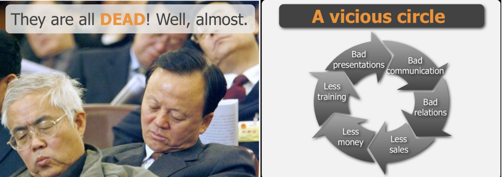

ちょっと話が逸れますが、特に国際会議における日本人の振る舞いは昔から3Sと言われてきました。原典はよくわかりませんが、この本には乗っていました：[“Competitive Global Management - Principles and Strategies”](https://www.crcpress.com/Competitive-Global-Management---Principles-and-Strategies/Alkhafaji/p/book/9781884015366) (Abbass Alkhafaji, 1995, Chap.8 Japan’s Economic Competitiveness, p.174)。

```
 HOW THE UNITED STATES VIEWS JAPAN
（アメリカは日本をどう見ているのか）

... Americans view the hard-working Japanese in five different ways: as sarcastic, prejudiced, frightening, having a superiority complex, and the learning opportunity. Few Americans actually want to learn from the Japanese.
（アメリカ人は日本の企業戦士に対して5つの心象を持っています。冷笑、僻み、恐れ、優越感、そして学習の機会です。実際のところ日本人から学ぼうというアメリカ人はほとんどいません。）

... Foreigners claim that Japanese participants at conferences are silent and "smile and sleep." Silence may be the custom in Japan, but it may not be an effective means of communication outside of Japan.
（海外からみると、会議における日本人の振る舞いを静か(silent)で、笑顔で(smile)、寝ている(sleep)と言及されています。沈黙は日本の風習かもしれませんが、日本の外では効果的な意志伝達手段では無いでしょう）
```

僕はこの3Sを大学院にいた頃に聞いたんですが、ま、何ていうか、国際学会に行っても決して笑顔は見せねーぞ、と思いましたね。

ただ、Death by PowerPointという言葉が生まれる程度には、退屈なトークは退屈だし眠くなります。実際、僕の観測範囲でも寝ているのは日本人だけに限りません。また日本人以外はみんな仏頂面なのかというとそんな事はなく基本的にフレンドリーだしジェントルです。のべつまくなし喋っているというわけでもありません。

にも関わらず、何故3Sと呼ばれるのか。「日本人のsmile」は、トークの内容や質問の内容を理解していない（ことを取り繕う）サインにも使われます。そこで何が分からないか聞き返さない「日本人のsilent」は意思伝達に対して消極的と受け取られます。これは根本的に英語の運用能力のハナシですね。とてもエキサイティングなトークでもこの能力が十分でなければ理解できない「日本人のsleep」になってしまいます（でも有名人のトークには取り敢えず出席するあたりがいかにも）。

これが致命的なのは懇親会です。会議では議事の進行に従ってとりあえず時は過ぎます。ただしその副作用として懇親会で時の流れがカタツムリの如くノロノロになります。ああなんで俺はここでこんな空虚な時間を…とか空を仰ぐハメになります。何故か。ハタから見ると自分のトークの時だけ事前に練習してきた内容を喋ってあとは黙ってるか寝てるか笑ってるかしてる。イコール、ああこのヒトはコミュニティに貢献する気がないんだなと認識されるからです。お互いオトナだし、それならそっとしておいてあげましょう。I’m Not Your Mother.

#### コミュニケーションのコスト

更に話が脱線しますが、「コミュ障」というのは酷い言葉ですね。こういう言葉の使い方をするから3Sになるんだと思います（あるいは表裏か）。言語能力や文化の差異によって自分がうまくコミュニケーション出来ない側に立った時に、「コミュ障」な立ち振る舞いで恥をさらす不安があると（本当は自分は「普通」なのに！）防衛的な振る舞いになってしまいます。 「コミュニケーション出来て普通」という認識は全く誤りです。相手が誰であろうと自分と違う独立した存在である以上、コミュニケーションのコストはゼロではありません。人類にはテレパシー能力は無いのです。思った事は伝えなければ伝わらない。

情報を伝わらない状態から伝わる状態に符号化(encode)するにはエネルギーが必要です。符号から情報を翻訳(decode)するにもエネルギーが必要です。対等なコミュニケーションでは双方のコストを平等に負担しましょう、ということです。より良い発表は、より良いコミュニケーション環境をもたらすはずです。何故なら、プレゼンテーションの事前準備に支払ったコストの分だけコミュニケーション・コストにゲタを履かせてもらえるからです。話を戻していくと、Deckの準備はまさにこれです。

トークの際に手元で参照するハンドアウトと、(99-pagerのような)Web上に公開する資料と、当日その場で映すスライドは、それぞれ異なった目的を持っているので最適なencode方法は本来異なっているはずです。Death by PowerPointはこれをサボった時に起こります。典型的なのは、もはや日本のお役所の伝統芸能と化している感のあるポンチ絵です。あれは伝えるための絵というより、何か聞かれた時に、あ、それはこの隅っこに米粒みたいに書いてありますよ、読んでないんですか？とやる防衛的な表現に見えます。少なくともトークのスライドとして最適化するコストを掛けていないか、誤ったベクトルで努力しています。Webで公開する資料として適切な符号だと言うのなら、まあ、お好きにどうぞという他ないですね。

ただしヒト1人が1つのプレゼンテーションに掛けられるコストは有限ですので、当日のスライドを完璧に仕上げることを優先したのでハンドアウトはおざなりになりました、ということもあるでしょう。何を重視されるかは分野や文化や目的によって異なります。聴き手がハンドアウトを重視する分野であればそこに重点的にコストを支払うべきです（恐らくお役所は何よりポンチ絵を重視する環境で、閉鎖的環境における書き手・読み手の共生的関係によってガラパゴス的な進化を遂げたのでしょう）。いずれにせよ、この意思伝達におけるencode, decodeのスキルは自然に身につくものでも「出来るのが普通」というものでもありません。

#### 勝利の方程式はあるのか

Death by PowerPointはいくつかの原則を挙げていますが、これを守っておけば良いというルールというよりは自分が目標とするコミュニケーションにおける最適手段を探索する上での手がかりとして読むのが良いかと思います。というのも誰がいつどう見るのかという点を考慮すると、コミュニティが変わればencodeが変わって当然だからです。むしろ新しいコミュニティの中に飛び込んでいく力を養いたいのであれば、自らの勝利の方程式を解体し、再編成していく、そこにきちんとコストを掛けていく体験が大切なのかもしれません。

2019年12月25日